# Dose-Response Estimation with HAL: Simulated and Real Data

Seraphina Shi

2025-07-04

# 1 1. Introduction

This document demonstrates how to use the **HAL-based plugin estimator** to estimate the **marginal causal dose-response curve** in both simulated and real data settings. The estimator uses **Highly Adaptive Lasso (HAL)** with optional undersmoothing to flexibly model the conditional outcome, enabling valid inference on marginal intervention contrasts.

We provide two simulated examples and one real data example: - A binary outcome setting - A continuous outcome setting - A real-data application using RHC study data

# 2 2. Simulated Data Examples

In this section, we simulate hypothetical datasets to validate the HAL-based dose-response estimator. These examples serve to: - illustrate the mechanics of generating potential outcomes under continuous interventions, - evaluate estimator performance under known data-generating mechanisms, - and visualize the agreement between estimated and true dose-response curves.

## 2.1 2.1 Binary Outcome Example

This example simulates a binary outcome $Y$, influenced by a continuous treatment $A$ and a baseline confounder $W$. The goal is to estimate the causal effect curve $\mathbb{E}[Y | do(A = a)]$ using the plugin estimator with HAL under a binomial outcome model.

We simulate data where: - $W$ is a baseline confounder - $A$ is a continuous treatment - $Y$ is a binary outcome depending on both $A$ and $W$

### 2.1.1 2.1.1 Generate Simulated Data

```r
set.seed(145)

generate_data <- function(n, a = NA){
  U_W <- rnorm(n)
  U_A <- rnorm(n, sd = 2)
  U_Y <- runif(n)
  W <- U_W

  if (is.na(a)) {
    A <- 2 - 0.5 * W + U_A
    A <- pmin(pmax(A, 0), 5)
  } else {
    A <- rep(a, n)
  }

  Y <- as.numeric(U_Y < plogis(-3 + 0.5*W + 1.25*A - 0.5*W*A))
  data.frame(W, A, Y)
}

obs <- generate_data(n = 500)
head(obs)
```

```
##           W         A Y
## 1 0.6869129 3.7840125 0
## 2 1.0663631 3.2232627 1
## 3 0.5367006 0.5392545 1
## 4 1.9060287 3.4649305 0
## 5 1.0631596 0.0000000 0
## 6 1.3703436 0.8576644 0
```

### 2.1.2 2.1.2 Estimate Dose-Response Curve

```r
DRC_fit_UAdaptive <- fit_UHAL_DRC(dat = obs, y_var_name = "Y", trt_var_name = "A", family = "binomial")
```

### 2.1.3 2.1.3 Visualize Estimated Curve

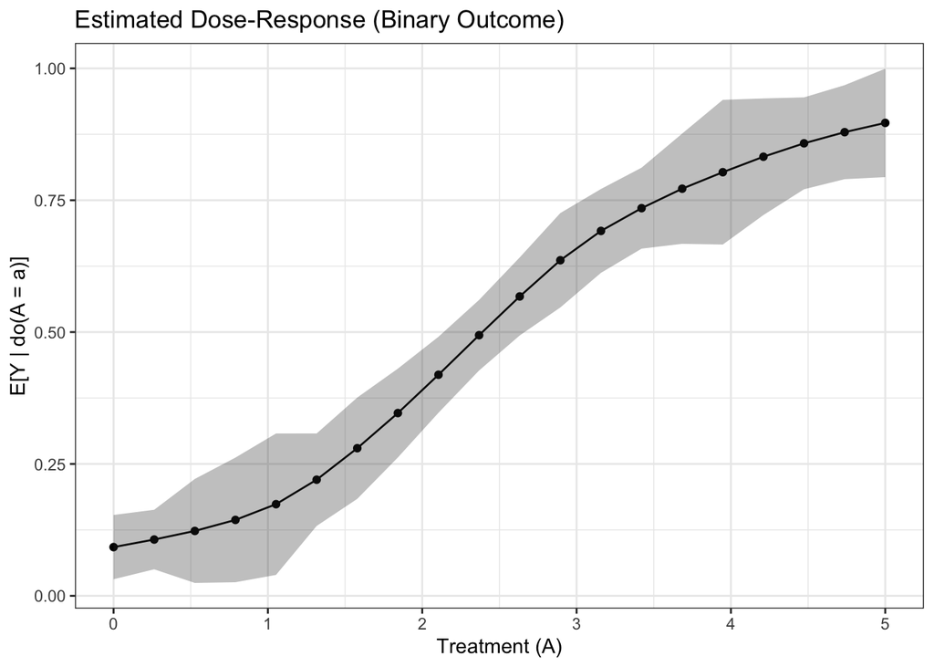

```r
df_ests <- DRC_fit_UAdaptive$curve_est

ggplot(df_ests, aes(x = a, y = y_hat)) +
  geom_line() +
  geom_point() +
  geom_ribbon(aes(ymin = ci_lwr, ymax = ci_upr), alpha = 0.3) +
  labs(title = "Estimated Dose-Response (Binary Outcome)",
       x = "Treatment (A)",
       y = "E[Y | do(A = a)]") +
  theme_bw()
```

### 2.1.4 2.1.4 Compare to True Curve

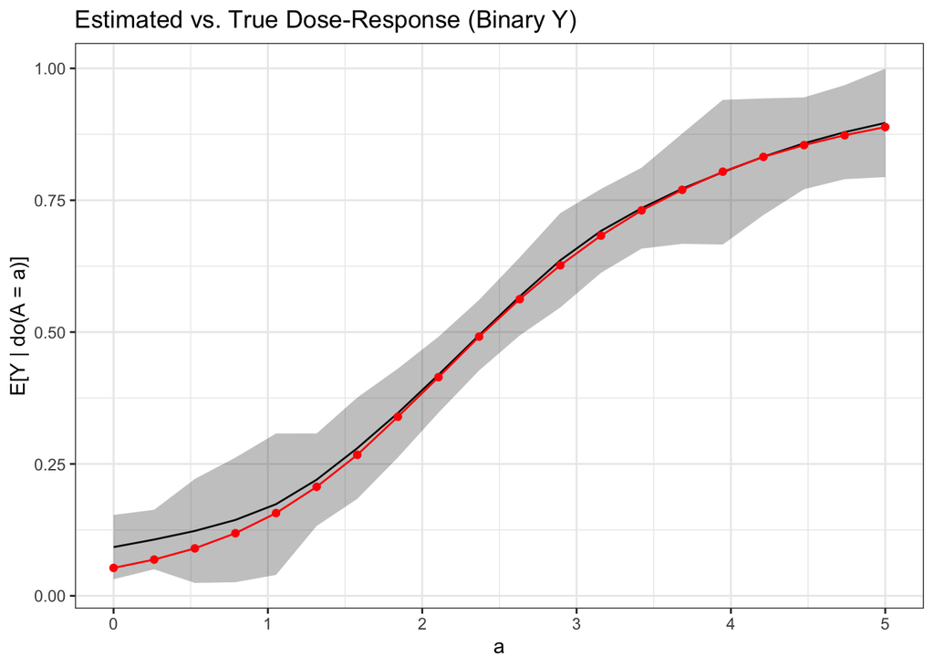

```r
a.vals <- seq(0, 5, length.out = 20)
psi0_a <- sapply(a.vals, function(a) mean(generate_data(n = 1e6, a = a)$Y))
psi0 <- data.frame(a = a.vals, psi0 = psi0_a)

ggplot(df_ests, aes(x = a, y = y_hat)) +
  geom_line() +
  geom_ribbon(aes(ymin = ci_lwr, ymax = ci_upr), alpha = 0.3) +
  geom_point(data = psi0, aes(x = a, y = psi0), color = "red") +
  geom_line(data = psi0, aes(x = a, y = psi0), color = "red") +
  labs(title = "Estimated vs. True Dose-Response (Binary Y)",
       y = "E[Y | do(A = a)]") +
  theme_bw()
```

## 2.2 2.2 Continuous Outcome Example

This simulation example uses a continuous outcome $Y$, which is a nonlinear function of treatment $A$ and baseline covariate $W$. This showcases how HAL handles nonlinear functional relationships and continuous outcomes. We again compare the estimated dose-response curve with the true curve obtained by Monte Carlo integration.

### 2.2.1 2.2.1 Simulate Continuous Outcome Data

```r
generate_data_2 <- function(n, a = NA) {
  U_W <- rnorm(n)
  U_A <- rnorm(n, sd = 0.8)
  U_Y <- rnorm(n, sd = 0.5)

  W <- U_W
  A <- if (is.na(a)) 0.5 * W + U_A else rep(a, n)
  logit_Y <- 0.5 * A^2 + A + 0.3 * W + U_Y
  Y <- 1 / (1 + exp(-logit_Y))
  data.frame(W, A, Y)
}

obs <- generate_data_2(n = 500)
```

### 2.2.2 2.2.2 Visualize Data

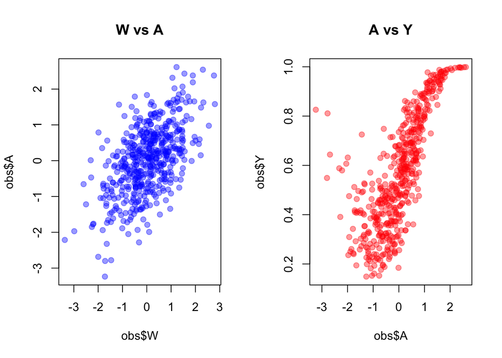

```r
par(mfrow = c(1, 2))
plot(obs$W, obs$A, main = "W vs A", pch = 19, col = rgb(0, 0, 1, 0.4))
plot(obs$A, obs$Y, main = "A vs Y", pch = 19, col = rgb(1, 0, 0, 0.4))
```

### 2.2.3 2.2.3 Estimate and Plot Dose-Response Curve

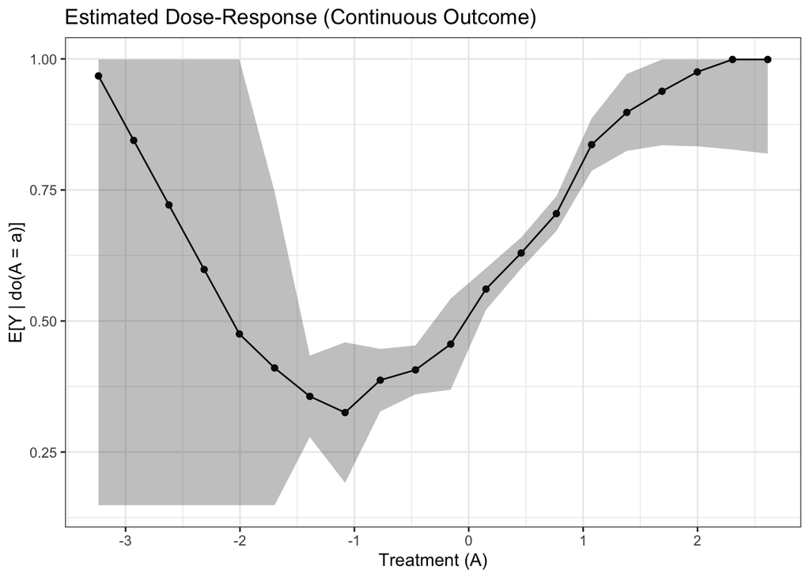

```r
DRC_fit_UAdaptive <- fit_UHAL_DRC(obs, "Y", "A", "gaussian")
df_ests <- DRC_fit_UAdaptive$curve_est

ggplot(df_ests, aes(x = a, y = y_hat)) +
  geom_line() +
  geom_point() +
  geom_ribbon(aes(ymin = ci_lwr, ymax = ci_upr), alpha = 0.3) +
  labs(title = "Estimated Dose-Response (Continuous Outcome)",
       x = "Treatment (A)",
       y = "E[Y | do(A = a)]") +
  theme_bw()
```

### 2.2.4 2.2.4 Compare to True Curve

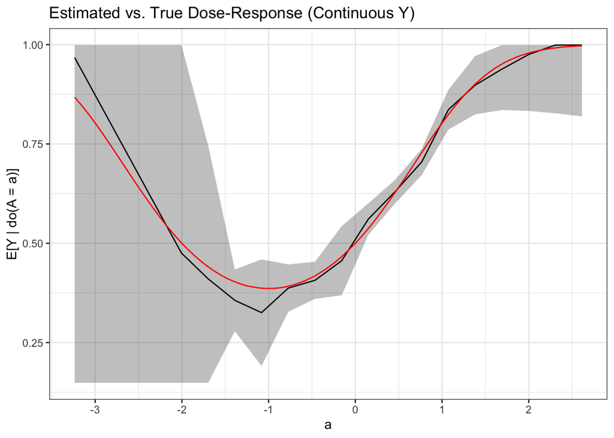

```r
a.vals <- seq(min(obs$A), max(obs$A), length.out = 100)
psi0 <- data.frame(
  a = a.vals,
  psi0 = sapply(a.vals, function(a) mean(generate_data_2(n = 1e6, a = a)$Y))
)

ggplot(df_ests, aes(x = a, y = y_hat)) +
  geom_line() +
  geom_ribbon(aes(ymin = ci_lwr, ymax = ci_upr), alpha = 0.3) +
  geom_line(data = psi0, aes(x = a, y = psi0), color = "red") +
  labs(title = "Estimated vs. True Dose-Response (Continuous Y)",
       y = "E[Y | do(A = a)]") +
  theme_bw()
```

# 3 3. Real Data Example: RHC Study

We now apply the HAL-based dose-response estimation procedure to real observational data from the **Right Heart Catheterization (RHC)** study. This data set includes detailed clinical variables and treatments administered to critically ill patients.

Our goal is to estimate the marginal causal effect of treatment intensity (here proxied by a synthetic “ProcedureCount” variable) on hospital length of stay, adjusting for baseline severity and biomarkers.

## 3.1 3.1 Load and Prepare RHC Data

In this section, we load the raw RHC dataset, construct the outcome variable (length of hospital stay), define the treatment (number of procedures), and select relevant clinical confounders. We also perform data cleaning and variable formatting to prepare the dataset for analysis.

```r
# Load raw dataset
ObsData <- read.csv("https://hbiostat.org/data/repo/rhc.csv", header = TRUE)

# Create outcome Y: length of stay
ObsData$Y <- ObsData$dschdte - ObsData$sadmdte
ObsData$Y[is.na(ObsData$Y)] <- ObsData$dthdte[is.na(ObsData$Y)] - ObsData$sadmdte[is.na(ObsData$Y)]

# Add synthetic ProcedureCount (used as A)
set.seed(145)
ObsData$ProcedureCount <- round(runif(nrow(ObsData), min = 0, max = 10), 0)

# Rename variables needed for analysis
ObsData <- ObsData %>%
  dplyr::rename(
    APACHE.score = aps1,
    DASIndex = das2d3pc,
    Creatinine = crea1,
    Bilirubin = bili1,
    WBC = wblc1,
    Heart.rate = hrt1
  )

# Subset to required columns for analysis
analysis_df <- ObsData %>%
  dplyr::select(
    Y,
    A = ProcedureCount,
    APACHE.score,
    DASIndex,
    Creatinine,
    Bilirubin,
    WBC,
    Heart.rate
  ) %>%
  na.omit()

# ℹ️ For computational efficiency in this demo, we randomly selected 1,000 observations from the full cleaned dataset for this HAL analysis.
set.seed(2025)
analysis_df <- analysis_df %>% sample_n(1000)

head(analysis_df)
```

```
##    Y A APACHE.score DASIndex Creatinine Bilirubin      WBC Heart.rate
## 1 21 6           66 17.04297   7.799805 0.5999756 31.39844        132
## 2 17 7           78 17.04297   2.500000 0.3999634 19.00000         28
## 3 21 1           76 14.75195   3.899902 0.1999817 14.00000        150
## 4  6 7           39 15.40625   1.199951 1.0097656 13.39844        115
## 5 19 5           63 24.00000   1.199951 1.1999512 14.00000        130
## 6  5 6           66 14.00000   1.899902 0.3999634 10.59961        167
```

## 3.2 3.2 Fit and Plot HAL Dose-Response Curve

Here, we apply the `fit_UHAL_DRC()` function to the real data and visualize the estimated marginal dose-response curve. This helps assess how treatment intensity is associated with patient outcomes after adjusting for confounding.

```r
DRC_fit_UAdaptive <- fit_UHAL_DRC(dat = analysis_df, y_var_name = "Y", trt_var_name = "A", family = "gaussian")
df_ests <- DRC_fit_UAdaptive$curve_est

head(df_ests)
```

```
##           a    y_hat       SE   ci_lwr   ci_upr
## 1 0.0000000 22.35758 4.859680 12.83261 31.88256
## 2 0.5263158 20.36055 2.382419 15.69101 25.03009
## 3 1.0526316 18.65867 1.870346 14.99279 22.32455
## 4 1.5789474 19.61320 1.562635 16.55043 22.67596
## 5 2.1052632 20.67491 2.042769 16.67108 24.67873
## 6 2.6315789 22.16536 2.017330 18.21139 26.11932
```

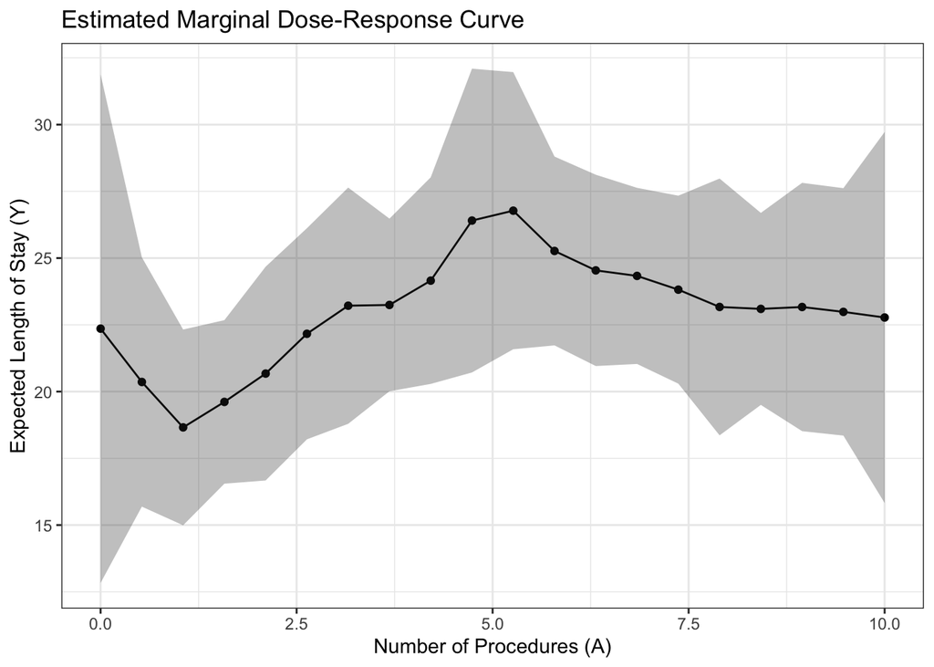

```r
ggplot(df_ests, aes(x = a, y = y_hat)) +
  geom_line() +
  geom_point() +
  geom_ribbon(aes(ymin = ci_lwr, ymax = ci_upr), alpha = 0.3) +
  labs(
    title = "Estimated Marginal Dose-Response Curve",
    x = "Number of Procedures (A)",
    y = "Expected Length of Stay (Y)"
  ) +
  theme_bw()
```

# 4 4. Summary

This unified demonstration shows how to apply the **HAL-based plugin estimator** to estimate **causal dose-response curves** for both simulated and real-world observational data. The method enables flexible functional modeling and valid inference, with clear application to diverse outcomes and settings.